# L1p1 Review

This is a review from the first lab of FPCC2 at the mastering course at UFCG.

Equipe: Ivan Aguiar de Almeida Manuel Severino da Silva Wesley Brenno Rodrigues Herculano

### 1.1 QUAL FOI O SÃO JOÃO MAIS FRIO EM CAMPINA GRANDE NOS ÚLTIMOS 20 ANOS?

Considerando o São João como o mês de Junho inteiro, temos que os anos de 2003, 2008, 2014, 2016 e 2018 tiveram as menores temperaturas mínimas (Entre 17.3 ºC e 17.6 ºC). Dentre esses, anos 2008 foi o ano que teve também a menor temperatura média (22.2 ºC) e a menor máxima (26.8 ºC). Assim, podemos considerar o ano de 2008 como o São João mais frio de Campina Grande.

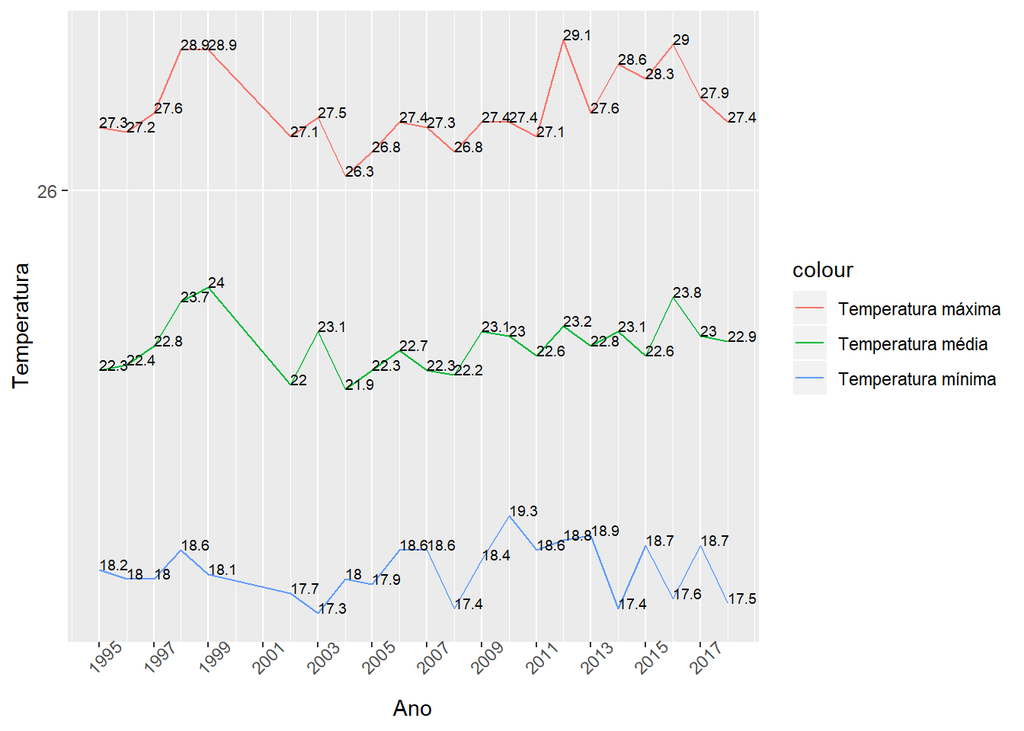

```r
climas %>%
  filter(cidade == "Campina Grande" & mes == 6) %>%
  group_by(ano) %>%
  summarise(temp_min = round(median(tmin),digits = 1), temp_max = round(median(tmax),digits = 1), temp_media = round(median(tmedia),digits = 1)) %>%
  ggplot() +
  geom_line(aes(x = ano, y = temp_max, colour = "Temperatura máxima")) +
  geom_text(aes(x = ano, y = temp_max,label=temp_max),hjust=0, vjust=0, size=2.5) +

  geom_line(aes(x = ano, y = temp_min, colour = "Temperatura mínima")) +
  geom_text(aes(x = ano, y = temp_min,label=temp_min),hjust=0, vjust=0, size=2.5) +

  geom_line(aes(x = ano, y = temp_media, colour = "Temperatura média")) +
  geom_text(aes(x = ano, y = temp_media, label=temp_media),hjust=0, vjust=0, size=2.5) +

  scale_x_continuous("Ano", breaks = seq(1995,2018,2)) +
  scale_y_continuous("Temperatura", breaks = seq(16,40,10)) +
  theme(axis.text.x = element_text(angle = 45))
```

### 1.2 A DISTRIBUIÇÃO DE CHUVAS É DIFERENTE EM MESES ESPECÍFICOS?

Realizando um agrupamento dos registros de chuva por mês, temos os gráfico abaixos, onde cada ponto representa um registro de chuva para o mês no eixo X, e quantidade no eixo Y. Pelos gráficos podemos perceber que durante os meses de Maio a Agosto há um aumento na quantidade de chuva e na quantidade de dias que chovem. É possível perceber também que os meses de Outubro, Novembro e Dezembro possuem uma distribuição muito parecida, assim como Janeiro, Fevereiro e Março também.

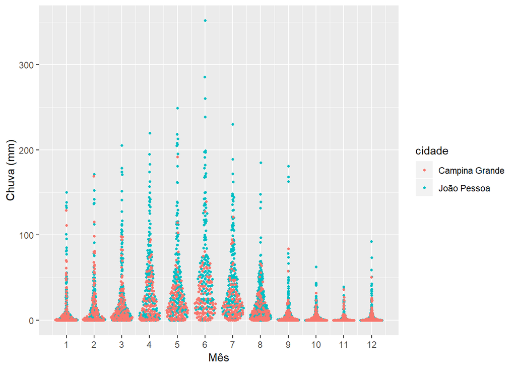

```r
climas %>%
    ggplot(aes(x=mes, y= chuva)) +
    geom_quasirandom(size=.90, aes(colour = cidade))  +
    scale_x_continuous("Mês", breaks = seq(1,12,1)) +
    scale_y_continuous("Chuva (mm)", breaks = seq(0,400,100))
```

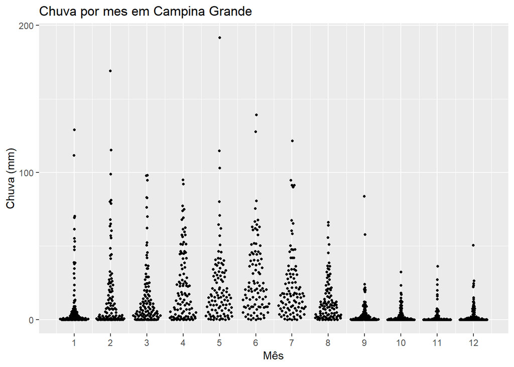

```r
climas %>%
    filter(cidade == "Campina Grande") %>%
    ggplot(aes(x=mes, y= chuva)) +
    geom_quasirandom(size=.90)  +
    scale_x_continuous("Mês", breaks = seq(1,12,1)) +
    scale_y_continuous("Chuva (mm)", breaks = seq(0,400,100)) +
    labs(
        title = "Chuva por mes em Campina Grande"
    )
```

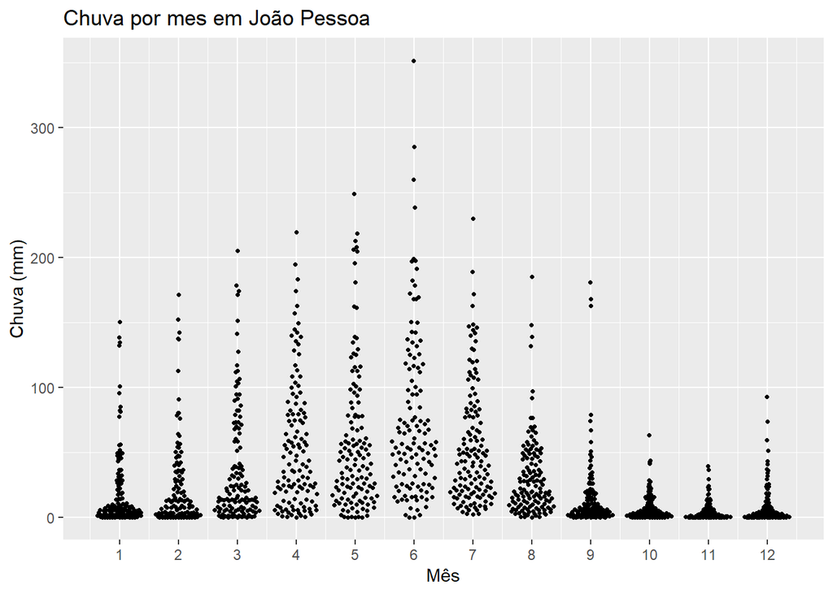

```r
climas %>%
    filter(cidade == "João Pessoa") %>%
    ggplot(aes(x=mes, y= chuva)) +
    geom_quasirandom(size=.90)  +
    scale_x_continuous("Mês", breaks = seq(1,12,1)) +
    scale_y_continuous("Chuva (mm)", breaks = seq(0,400,100)) +
    labs(
        title = "Chuva por mes em João Pessoa"
    )
```